# Scholarship

Shiqi Ning

5/20/2019

# What Do Graduate Schools Look For In A Successful Applicant?

## Description

This Mini-Project narratives the Story about “What Do Graduate Schools Look For In A Successful Applicant?” Determines the most important features during admission process Data used: pretended dataset emulating student data

## Introduction

### Background

Applying for graduate schools or programs can be an overwhelming process, especially when your targeting dream school has a competitive candidate pool. Normally, graduate schools will require a tremendous amount of supporting documents from each of their applicants. Commonly seen documents including but no limited to personal statements/essays, Undergraduate GPA, Graduate Record Examinations (GRE)/Graduate Management Admission Test (GMAT) score, at least 2 letters of recommendations, and even professional working experience, etc. can be requested to help the schools select the most ideal and promising students.

### Supporting Documents

Interestingly, different from the selection process of undergraduate institutions, graduate schools’ acceptances are usually separated into specific programs or departments, not for the entire institutions; and each program or department has its own and distinct scheme to choose the ideal students. Additionally, for those applicants who already received the offer, but have not yet accepted the offer, schools will allow an extension for them to accept their offers, giving the students they valued a lot more time to considerate. So, do applicants with certain backgrounds or majors more favored during the selection process even if an offer is granted, is there any gender-related bias during the Admission process, or do races matter in such process are all interesting aspects that can be further investigated.

### Goal

Understanding how each criteria actually separates you from other candidates and what do admissions committees eager to see during their selecting process are the keys to success. Thus, this mini project will try to investigate how different factors like GPA, GRE, Major, Gender, Races, etc. weight during admission process.

## Exploratory Data Analysis

### About the DataSet

```r
library(tree)
library(ggplot2)
library(randomForest)
require(graphics)
require(rafalib)
library(psych)
library(pROC)
# Load dataset
data = read.csv("ScholarshipApplicationDataFilePretend.csv")
head(data)
```

```
##    ID OfferOfAdmissionExtended  GPA GRE TOEFL       Major CollegeRegion
## 1   1                      YES 3.34 168   111  Management         Spain
## 2 104                      YES 3.82 170    NA  Statistics           USA
## 3   3                      YES 3.79 159    NA Engineering         India
## 4   4                      YES 3.77 160    NA          CS           USA
## 5   5                      YES 3.91 168    NA        Math           USA
## 6 128                      YES 3.84 168    NA  Statistics           USA
##   CollegeName    State Dom_Int Matriculating Gender UniRank
## 1       Spain     <NA>     INT            NO   Male      NA
## 2      Urbana Illinois     DOM            NO Female      46
## 3        NUST     <NA>     INT            NO   Male      NA
## 4    Illinois Illinois     DOM            NO   Male      46
## 5       Texas    Texas     DOM            NO   Male      49
## 6      Urbana Illinois     DOM            NO Female      46
```

```r
data2 = read.csv("ScholarshipApplicationDataFilePretend2.csv")
```

```r
# Check data structure and check NA values count
dim(data)
```

```
## [1] 381  13
```

```r
str(data)
```

```
## 'data.frame':    381 obs. of  13 variables:
##  $ ID                      : int  1 104 3 4 5 128 7 8 179 10 ...
##  $ OfferOfAdmissionExtended: Factor w/ 2 levels "NO","YES": 2 2 2 2 2 2 2 2 2 2 ...
##  $ GPA                     : num  3.34 3.82 3.79 3.77 3.91 3.84 3.69 3.67 3.51 3.94 ...
##  $ GRE                     : int  168 170 159 160 168 168 170 169 170 170 ...
##  $ TOEFL                   : int  111 NA NA NA NA NA NA NA NA 110 ...
##  $ Major                   : Factor w/ 10 levels "Accounting","CS",..: 6 10 4 2 7 10 10 4 4 3 ...
##  $ CollegeRegion           : Factor w/ 11 levels "Canada","China",..: 9 11 3 11 11 11 11 2 11 4 ...
##  $ CollegeName             : Factor w/ 66 levels "Arizona","Berkeley",..: 57 61 45 27 58 61 43 10 61 31 ...
##  $ State                   : Factor w/ 31 levels "Arizona","California",..: NA 9 NA 9 28 9 9 NA 9 NA ...
##  $ Dom_Int                 : Factor w/ 2 levels "DOM","INT": 2 1 2 1 1 1 1 2 1 2 ...
##  $ Matriculating           : Factor w/ 2 levels "NO","YES": 1 1 1 1 1 1 1 1 2 1 ...
##  $ Gender                  : Factor w/ 2 levels "Female","Male": 2 1 2 2 2 1 2 2 2 1 ...
##  $ UniRank                 : int  NA 46 NA 46 49 46 10 NA 46 NA ...
```

```r
colSums(is.na(data))
```

```
##                       ID OfferOfAdmissionExtended                      GPA
##                        0                        0                        0
##                      GRE                    TOEFL                    Major
##                        4                      252                        0
##            CollegeRegion              CollegeName                    State
##                        0                        0                      156
##                  Dom_Int            Matriculating                   Gender
##                        0                        0                        0
##                  UniRank
##                      158
```

```r
#which(data == colSums(is.na(data)))

# Delete NA values
#data[!complete.cases(data), ]

# Check rows with NA values in each column
data[is.na(data$GRE),]
```

```
##      ID OfferOfAdmissionExtended  GPA GRE TOEFL      Major CollegeRegion
## 53   53                      YES 3.58  NA   106 Management         China
## 162 162                      YES 3.51  NA   108  Economics         China
## 167 167                      YES 3.52  NA    NA       Math           USA
## 302 302                       NO 3.17  NA    NA Management           USA
##     CollegeName          State Dom_Int Matriculating Gender UniRank
## 53        China           <NA>     INT            NO Female      NA
## 162       China           <NA>     INT            NO   Male      NA
## 167  California     California     DOM            NO   Male      30
## 302     Clemson South Carolina     DOM            NO Female      66
```

```r
data[is.na(data$TOEFL),]
```

```
##      ID OfferOfAdmissionExtended  GPA GRE TOEFL       Major CollegeRegion
## 2   104                      YES 3.82 170    NA  Statistics           USA
## 3     3                      YES 3.79 159    NA Engineering         India
## 4     4                      YES 3.77 160    NA          CS           USA
## 5     5                      YES 3.91 168    NA        Math           USA
## 6   128                      YES 3.84 168    NA  Statistics           USA
## 7     7                      YES 3.69 170    NA  Statistics           USA
## 8     8                      YES 3.67 169    NA Engineering         China
## 9   179                      YES 3.51 170    NA Engineering           USA
## 11   11                      YES 3.84 167    NA        Math           USA
## 13   13                      YES 3.97 165    NA        Math           USA
## 14  211                      YES 3.46 168    NA        Math           USA
## 16   16                      YES 3.80 164    NA  Management           USA
## 17   17                      YES 3.24 167    NA  Accounting         China
## 20   20                      YES 3.43 170    NA        Math         China
```

[output cut: 491 more lines]

```r
data[is.na(data$State),]
```

```
##      ID OfferOfAdmissionExtended  GPA GRE TOEFL       Major CollegeRegion
## 1     1                      YES 3.34 168   111  Management         Spain
## 3     3                      YES 3.79 159    NA Engineering         India
## 8     8                      YES 3.67 169    NA Engineering         China
## 10   10                      YES 3.94 170   110   Economics         Korea
## 12   12                      YES 3.79 170   109  Statistics         China
## 15   15                      YES 3.58 170   102  Statistics         China
## 17   17                      YES 3.24 167    NA  Accounting         China
## 19   19                      YES 3.93 170   113     Finance         China
## 20   20                      YES 3.43 170    NA        Math         China
## 25   25                      YES 3.03 166    NA Engineering           USA
## 28   28                      YES 3.67 169   105     Finance         China
## 29   29                      YES 3.65 170   105        Math         China
## 32   32                      YES 3.68 170   108       Other         China
## 35   35                      YES 3.82 169   105  Accounting         China
```

[output cut: 299 more lines]

```r
# Count number of rows where Dom_Int = INT
nrow(data[data["Dom_Int"] == "INT",])
```

```
## [1] 157
```

```r
data[data["Dom_Int"] == "INT",]
```

```
##      ID OfferOfAdmissionExtended  GPA GRE TOEFL       Major CollegeRegion
## 1     1                      YES 3.34 168   111  Management         Spain
## 3     3                      YES 3.79 159    NA Engineering         India
## 8     8                      YES 3.67 169    NA Engineering         China
## 10   10                      YES 3.94 170   110   Economics         Korea
## 12   12                      YES 3.79 170   109  Statistics         China
## 15   15                      YES 3.58 170   102  Statistics         China
## 17   17                      YES 3.24 167    NA  Accounting         China
## 19   19                      YES 3.93 170   113     Finance         China
## 20   20                      YES 3.43 170    NA        Math         China
## 28   28                      YES 3.67 169   105     Finance         China
## 29   29                      YES 3.65 170   105        Math         China
## 32   32                      YES 3.68 170   108       Other         China
## 35   35                      YES 3.82 169   105  Accounting         China
## 36   36                      YES 4.00 170   105   Economics         China
```

[output cut: 301 more lines]

```r
# Suffle data
#df2 <- slice(data, sample(1:n()))
```

### Data Preparation

#### Data Cleaning & Future Generation

As mentioned above, there exists both NA values and outliers in the dataset, which need to be dealt with, the following methodologies were used:

GRE: since GRE could be an important measurement, and there is only a limited amount of observations, simply remove the NA values is not valid, so the NA values in GRE were replaced by the mean GRE. TOEFL: TOEFL score is one of the important measurement to check whether an international students satisfy the basic requirements for English communication. And after carefully examining the dataset, the NA values in TOEFL do appear most likely from domestic students, or international students who attended US-based undergraduate institutions, where they are not required to submit a TOEFL score. Thus, the column was regenerated as TOEFLcut where NA values were replaced with “waived”, and the rest of the score were binned into 4 groups: 110 ~ 120 are labeled as 1, 100 ~ 110 are labeled as 2, 90 ~ 100 are labeled as 3, and scores below 90 are labeled as 4. State: the NA values in State are mostly to be students who did not attend a US-based university/college, and since almost half of the State is NA and it does not seem to contribute a lot for the purpose of our goal, this column is removed. Outlier: the observation contains the outlier is removed.

```r
# Delete rows with chosen column value
data = data[data["ID"] != 113,]
# test$state_class = 0
# test$state_class[test$quality >= 6] = 1
# test$state_class = data$class

# Add level to factor variable
data$State = factor(data$State, levels=c(levels(data$State), 'Unknown'))
data$State[is.na(data$State)] = 'Unknown'

# Feature generation
data$TOEFLcut = cut(data$TOEFL, breaks = c(-Inf, 90,100,110,120), include.lowest = TRUE, labels=4:1)
data$TOEFLcut = factor(data$TOEFLcut, levels=c(levels(data$TOEFLcut), 'Waived'))
data$TOEFLcut[is.na(data$TOEFLcut)] = 'Waived'

# Replace na values with mean
data$GRE = ifelse(is.na(data$GRE), mean(data$GRE, na.rm=TRUE), data$GRE)

data$rank = cut(data$UniRank, c(-Inf, 11,29,60,80, Inf),include.lowest = TRUE, labels=1:5)
```

```r
# Print table
table(is.na(data$TOEFL), data$Dom_Int)
```

```
##
##         DOM INT
##   FALSE   7 121
##   TRUE  217  35
```

```r
table(data$CollegeRegion, data$OfferOfAdmissionExtended)
```

```
##
##                  NO YES
##   Canada          0   1
##   China          54  83
##   India           3   2
##   Korea           0   1
##   Pakistan        1   0
##   Scotland        1   1
##   Singapore       0   1
##   South America   1   0
##   Spain           0   1
##   UK              0   4
##   USA            53 173
```

```r
table(data$Gender, data$OfferOfAdmissionExtended)
```

```
##
##           NO YES
##   Female  57 153
##   Male    56 114
```

### Cluster Analysis for Major

As mentioned above, there may exist underlying information for each Major group, thus a cluster analysis for Major is performed, so that it is possible to check whether the same Major would be clustered together. The data contains both numerical and categorical data, so hierarchical clustering with method = “complete” was chosen, which can better handle such situation.

Since the Major is the response that matters, only a subset of attributes were used to perform cluster analysis, which are:

GPA GRE Gender TOEFLcut

```r
set.seed(810)

x = subset(data, select=-c(ID, TOEFL, Major, CollegeRegion, CollegeName, State, UniRank, OfferOfAdmissionExtended, Dom_Int, Matriculating, rank))

x$Gender = ifelse(x$Gender == "Male", 1, 0)

# # Compute principal componants
# pca_10a = prcomp(as.data.frame(x))
#
# # Calculate the proportion of variance explained by PC
# pca_var_10a = pca_10a$sdev^2
#
# # Calculate the fraction of the variance each principal component has explained
# pca_per_10a = round(pca_var_10a/sum(pca_var_10a)*100, 2)
#
# # Plot
# n_10a = 25
# plot_10a <- barplot(pca_per_10a[1:n_10a], main = "Fraction of Variance Explained By Each PC %", xlab = "Principal Component", ylab = "Fraction explained", col = "lightsalmon2", ylim = c(0, 40))
# # Add text at top of bars
# text(x = plot_10a, y = pca_per_10a[1:n_10a], label = pca_per_10a[1:n_10a], pos = 3, cex = 0.8, col = "aquamarine4")
# # Add x-axis labels
# axis(1, at = plot_10a, labels = paste0("PC", 1:n_10a), tick = FALSE, las = 2, line = -0.5, cex.axis = 0.5)
```

```r
hist = hclust(dist(x), method = "complete")
groups = cutree(hist, k = 10)
table(data$Major, groups)
```

```
##              groups
##                1  2  3  4  5  6  7  8  9 10
##   Accounting   6  0  1  0  0  0  0  0  0  0
##   CS          14  1 12  0  2  0  1  0  1  0
##   Economics   21  2 14  3  1  1  0  1  0  0
##   Engineering 18  1  8  3  1  3  0  0  1  0
##   Finance     11  0  3  1  1  0  0  0  0  0
##   Management  14  1  9  1  1  0  0  0  0  1
##   Math        69  1 27  6  5  2  0  1  0  0
##   Other       29  1  6  2  2  2  1  0  0  0
##   Physics      3  0  0  2  0  0  0  0  0  0
##   Statistics  39  0 13  5  2  1  2  0  0  0
```

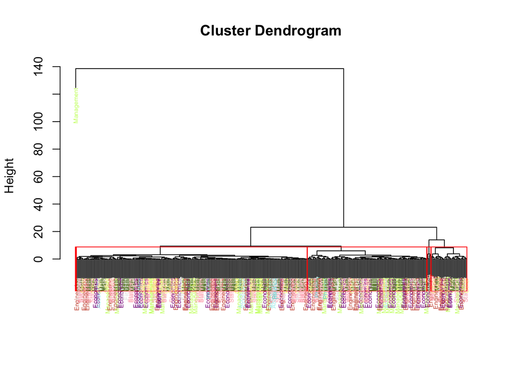

```r
color_list = rep(NA, length = length(data$Major))
color_list[which(data$Major == "Accounting")] = "paleturquoise"
color_list[which(data$Major == "CS")] = "antiquewhite1"
color_list[which(data$Major == "Economics")] = "darkmagenta"
color_list[which(data$Major == "Finance")] = "gray90"
color_list[which(data$Major == "Management")] = "darkolivegreen1"
color_list[which(data$Major == "Math")] = "darkolivegreen4"
color_list[which(data$Major == "Other")] = "khaki1"
color_list[which(data$Major == "Physics")] = "darkslategray3"
color_list[which(data$Major == "Statistics")] = "lightpink"
color_list[which(data$Major == "Engineering")] = "coral3"

myplclust(hist, labels = data$Major, lab.col = color_list, cex=0.5)
rect.hclust(hist, k = 5, border="red")
```

From the above dendrogram, even though the nodes is not so clear, but from the color separation, it is clear that there is no convincing evidence that supports the assumption where candidates who share the same majors would have similar standardized test performances, such as similar GPA, GRE, etc..

## Find the most important Features

```r
# Prepare dataset
index = sample(1:nrow(data), nrow(data)*0.7)
train = data[index, ]
test = data[-index, ]
```

### Random Forest

Since the goal for this mini project is to investigate how different factors like GPA, GRE, Major, Gender, Domestic or International status, etc. weight during admission process, random forest was performed. Random forest can help to determine the most important features in a dataset. And it is also one of the most accurate algorithm that produces an accurate classifier, and also at the same time reduce the risk of overfitting.

The OfferOfAdmissionExtended attribute is treated as the response, since it reflects how Admission office value their candidates. The predictors in this case are: GPA, GRE, Major, Dom_Int, Gender, TOEFLcut and Rank, below are the feature importance plots: Mean Decrease Accuracy and Mean Decrease Gini

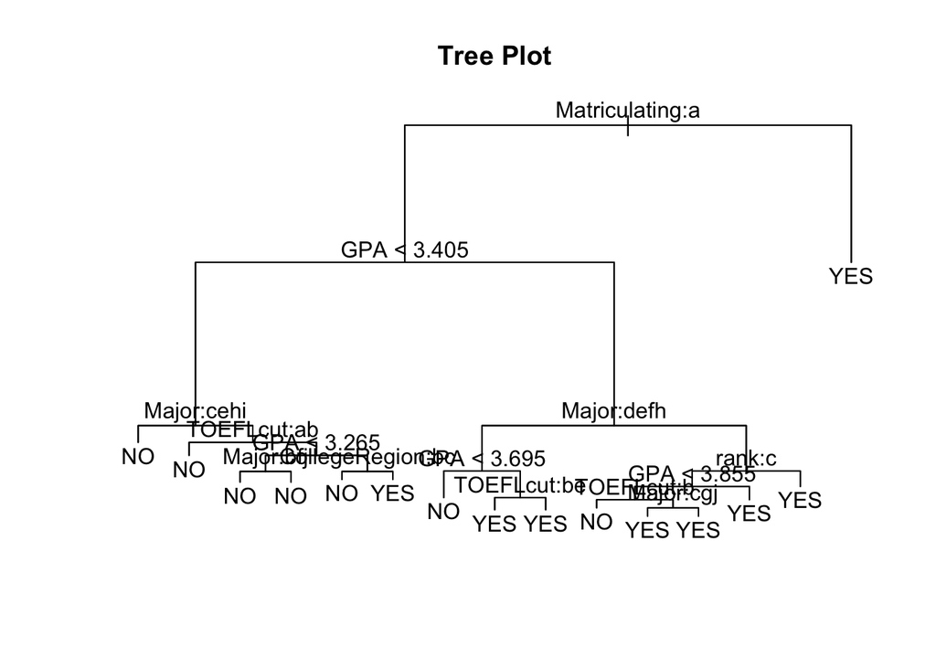

```r
# Fit a tree to the training data
tree_7 =  tree(OfferOfAdmissionExtended ~ .- ID - CollegeName - State - TOEFL -GRE, data = data, na.action = na.roughfix)
#summary(tree_7)

# Plot the tree
plot(tree_7)
text(tree_7)
title("Tree Plot")
```

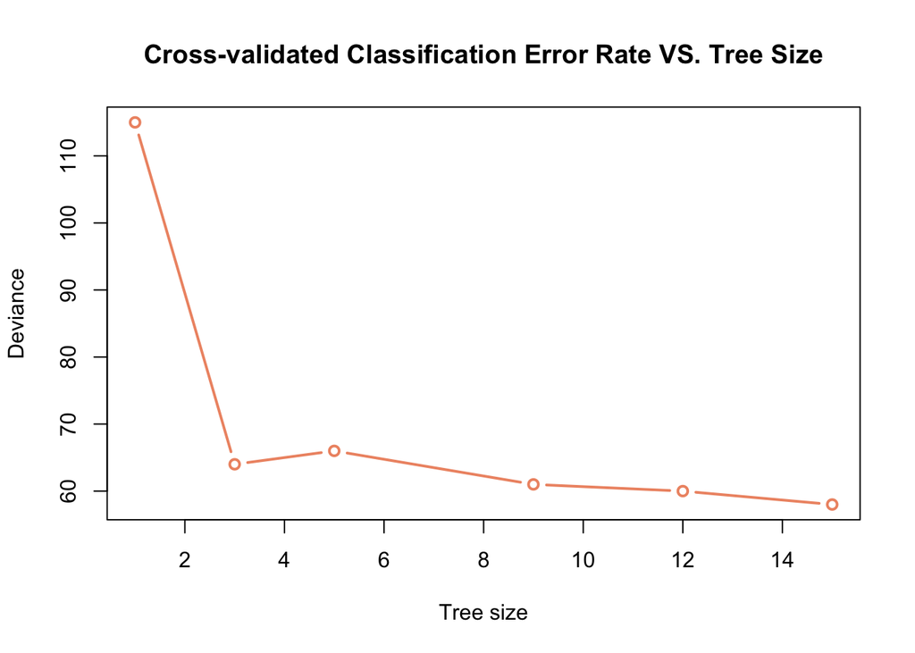

```r
# Apply the cv.tree() function to the training set to determine the optimal tree size.
cv_7 = cv.tree(tree_7, FUN = prune.misclass)
#cv_7

# Plot the CV Classification Error Rate VS. Tree Size
plot(cv_7$size, cv_7$dev, type = "b", xlab = "Tree size", ylab = "Deviance", main = "Cross-validated Classification Error Rate VS. Tree Size", col = "lightsalmon2", lwd = 2)
```

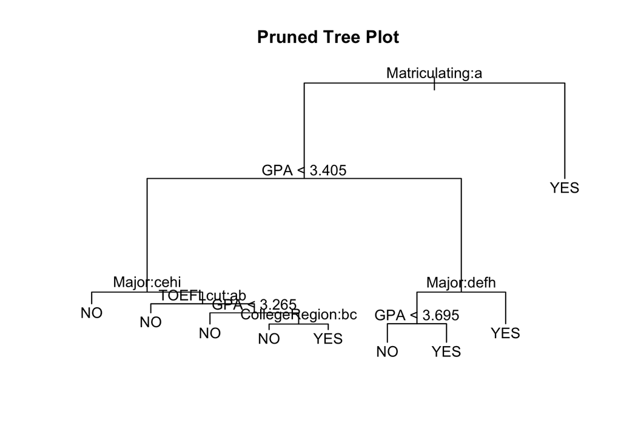

```r
# Plot the pruned tree
prune_7 = prune.misclass(tree_7, best = 8)
plot(prune_7)
text(prune_7)
title("Pruned Tree Plot")
```

```r
# Predict the prunned tree and make a confusion matrix
prune_pred_7 = predict(prune_7, test, type = "class")
conf_mat_prune = table(prune_pred_7, test$OfferOfAdmissionExtended)

# Compute the test error rate
test_error_prune_7 = (conf_mat_prune[1,2] + conf_mat_prune[2,1])/nrow(test)


cat("The classification error rate for the pruned tree from the test data is", test_error_prune_7)
```

```
## The classification error rate for the pruned tree from the test data is 0.1754386
```

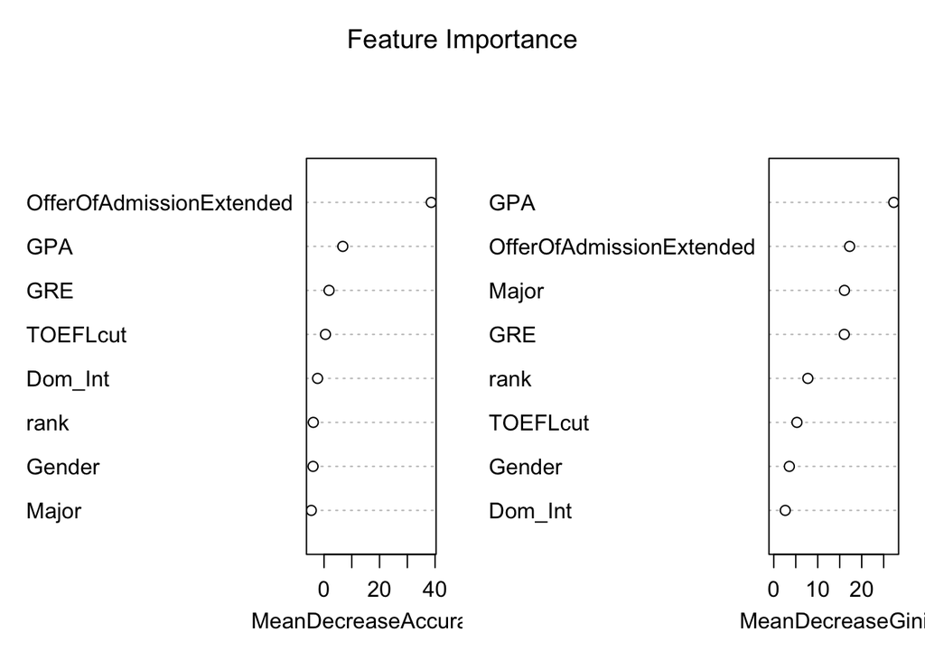

```r
#tree1 = tree(OfferOfAdmissionExtended ~ .- ID - CollegeName - State, data = data, na.action = na.roughfix)
#tree1 = randomForest(OfferOfAdmissionExtended ~ .- ID - CollegeName - State - GRE - TOEFL, data = data)
#tree1 = tree(OfferOfAdmissionExtended ~ .- ID - CollegeName - State - TOEFL -GRE, data = data, na.action = na.roughfix)

#tree1 = randomForest(OfferOfAdmissionExtended ~ .- ID - CollegeName - College - State - TOEFL , data = data, na.action = na.roughfix, importance = TRUE)
tree1 = randomForest(Matriculating ~ OfferOfAdmissionExtended + GPA + GRE+ Major+ Dom_Int+ Gender+ TOEFLcut+ rank , data = data, na.action = na.roughfix, importance = TRUE)

tree2 = randomForest(OfferOfAdmissionExtended ~ GPA + GRE+ Major+ Dom_Int+ Gender + TOEFLcut+ rank , data = data, na.action = na.roughfix, importance = TRUE)

#plot_tree(tree, nodelabf=nodeplotboot(), ladderize="left", color="SampleType")
# Plot the tree
# plot(tree1)
# text(tree1)
# title("Tree Plot")

varImpPlot(tree1, main = "Feature Importance")
```

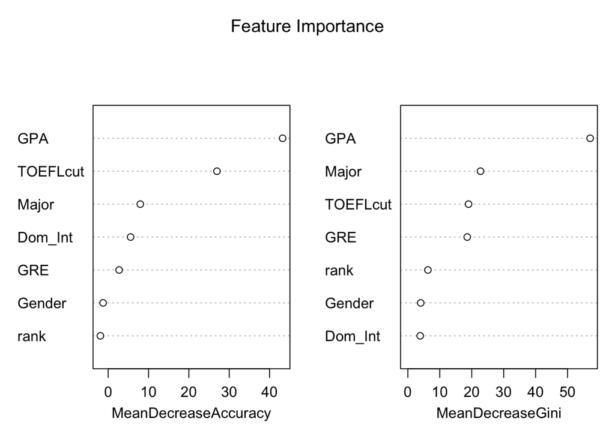

```r
varImpPlot(tree2, main = "Feature Importance")
```

From the above plots, it is clear that the three most important features are GPA, Major and TOEFLcut. Intuitively, this result also makes sense, since the standardized test results are the most direct evidence of a candidate’s qualification, and even though similar majors make not share similar underlying traits, some of the majors can still be more preferable than others. Then, these three attributes will be used to make predictive model using the Logistic Regression Algorithm.

### Logistic Regression

Logistic Regression model is a predictive analysis tool that uses a logistic function to model a binary variable, which is suitable for the purpose of this mini project. And the data is split into training (70%) and test (30%) set to check the performance of the model. And the ROC curve of the test set result is shown below:

```r
fit_full = glm(OfferOfAdmissionExtended  ~ Major + GPA+ TOEFLcut, data = train, family = binomial)

fit_full_2 = glm(Matriculating  ~  OfferOfAdmissionExtended + GPA+ TOEFLcut, data = train, family = binomial)
probs_full = predict(fit_full, test, type="response")

# Confusion matrix
pred_full = ifelse(probs_full > 0.6, 1, 0)
table_full = table(pred_full, test$OfferOfAdmissionExtended)
table_full
```

```
##
## pred_full NO YES
##         0 25  14
##         1 18  57
```

```r
# Function calculating the prediction error
predict_error = function(conf_mat){
  error = (conf_mat[1,2] + conf_mat[2,1])/(conf_mat[1,1] + conf_mat[1,2] + conf_mat[2,1] + conf_mat[2,2])
  accuracy = (conf_mat[1,1] + conf_mat[2,2])/(conf_mat[1,1] + conf_mat[1,2] + conf_mat[2,1] + conf_mat[2,2])
  return(error)
}
# Print our results
cat("\nThe prediction accuracy for Naive Bayes on test set is", 1 - predict_error(table_full))
```

```
##
## The prediction accuracy for Naive Bayes on test set is 0.7192982
```

```r
cat("\nThe prediction error for Naive Bayes on test set is", predict_error(table_full))
```

```
##
## The prediction error for Naive Bayes on test set is 0.2807018
```

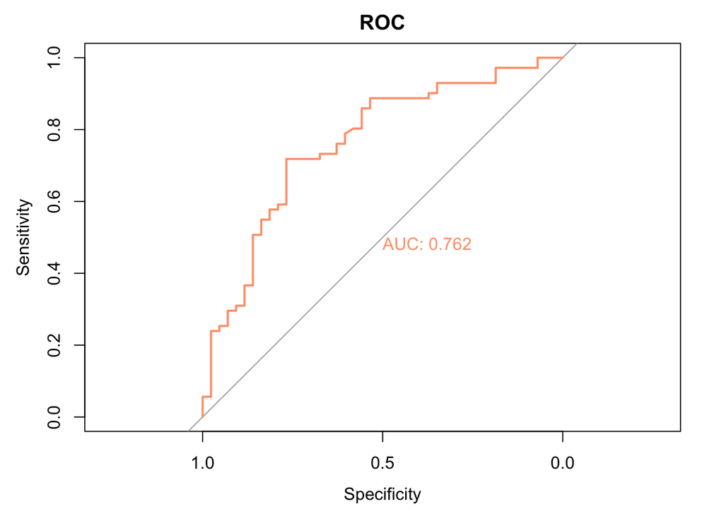

```r
# Plot the roc curve and calculate the auc
plot(roc(test$OfferOfAdmissionExtended, probs_full), print.auc = TRUE, col = "lightsalmon1", main = "ROC")
```

## Conclusion

· The goal for this mini project is to investigate how different factors like GPA, GRE, Major, Gender, Domestic/International, etc. weight during admission process. During exploratory data analysis, feature selection and predictive model analysis, there are some enlightening relationship arised:

## Future Work

· Since the data is synthetic, there is limited amount of information that can be extracted. · For more detailed results, it would be great to find more information about each attribute. For instance, figure out what section does the GRE score represent, verbal or quantitative; detailed College names, etc. · More interesting factors can be added to make the prediction model more robust, such as whether the students have previous working experience, scholarship winning experience, or have participated and contributed in various interesting projects. · Can also investigate which factors affect Matriculating, OfferOfAdmissionExtended, GRE, etc., and run the logistic regression model again to see the classification results.